任务： 1.分割数据集 2.优化梯度下降算法 2.1 不使用任何优化算法 2.2 mini-batch 梯度算法 2.3 使用具有动量的梯度算法 2.4 使用Adma算法

# step1：导入数据包

```python
import numpy as np
import matplotlib.pyplot as plt
import sklearn
import sklearn.datasets
import testCase
plt.rcParams['figure.figsize'] = (7.0,4.0)  #set default size of plots
plt.rcParams['image.interpolation'] = 'nearest'
plt.rcParams['image.cmap'] = 'gray'
```

1.典型的梯度下降

```python
def update_parameters_with_gd(parameters,grads,learning_rate):
    L = len(parameters)//2
    for i in range(L):
        parameters['W'+str(1+i)] = parameters['W'+str(1+i)]-learning_rate*grads['dW'+str(1+i)]
        parameters['b'+str(1+i)] = parameters['b'+str(1+i)]-learning_rate*grads['db'+str(1+i)]
    return parameters
```

```python
#测试update_parameters_with_gd
print("-------------测试update_parameters_with_gd-------------")
parameters , grads , learning_rate = testCase.update_parameters_with_gd_test_case()
parameters = update_parameters_with_gd(parameters,grads,learning_rate)
print("W1 = " + str(parameters["W1"]))
print("b1 = " + str(parameters["b1"]))
print("W2 = " + str(parameters["W2"]))
print("b2 = " + str(parameters["b2"]))
```

```
-------------测试update_parameters_with_gd-------------
W1 = [[ 1.63535156 -0.62320365 -0.53718766]
 [-1.07799357  0.85639907 -2.29470142]]
b1 = [[ 1.74604067]
 [-0.75184921]]
W2 = [[ 0.32171798 -0.25467393  1.46902454]
 [-2.05617317 -0.31554548 -0.3756023 ]
 [ 1.1404819  -1.09976462 -0.1612551 ]]
b2 = [[-0.88020257]
 [ 0.02561572]
 [ 0.57539477]]
```

2.随机梯度下降（SGD） 解释：随机梯度每一个mini-batch都只有1个样本， 梯度下降就是mini-batch是整个训练集 mini-batch梯度下降就是mini-batch介于这两者之间

```python
#1.加载数据
def load_data(is_plot=True):
    np.random.seed(2018)
    train_x,train_y = sklearn.datasets.make_circles(n_samples=500,noise=0.05)
    np.random.seed(2017)
    test_x,test_y = sklearn.datasets.make_circles(n_samples=100,noise=0.05)
    if is_plot:
        plt.scatter(train_x[:,0],train_x[:,1],c=train_y,s=40,cmap=plt.cm.Spectral)
    train_x = train_x.T
    train_y = train_y.reshape((1,train_y.shape[0]))

    test_x = train_x.T
    test_y = test_y.reshape((1,test_y.shape[0]))
    return train_x,train_y,test_x,test_y
##初始化参数（采用随机初始化）
def init(layers_dims):
    parameters = {}
    for key in range(len(layers_dims)-1):
        parameters['W'+str(key+1)] = np.random.rand(layers_dims[key+1],layers_dims[key])
        parameters['b'+str(key+1)] = np.random.rand(layers_dims[key+1],1)
    return parameters
##定义relu函数
def relu(X):
    result = np.maximum(0,X)
    return result
##定义sigmod函数
def sigmod(X):
    return 1/(1+np.exp(-X))
##向前传播函数
def forward_propagation(X,parameters):
    W1 = parameters['W1']
    b1 = parameters['b1']
    W2 = parameters['W2']
    b2 = parameters['b2']
    W3 = parameters['W3']
    b3 = parameters['b3']
    z1 = parameters['W1'].dot(X)+parameters['b1']
    a1 = relu(z1)

    z2 = parameters['W2'].dot(a1)+parameters['b2']
    a2 = relu(z2)

    z3 = parameters['W3'].dot(a2)+parameters['b3']
    a3 = sigmod(z3)

    cache = (z1, a1, W1, b1, z2, a2, W2, b2, z3, a3, W3, b3)

    return a3,cache
##计算损失函数
def computer_cost(y_heat,y):
    m = y.shape[1]
    cost = (-1/m)*np.sum(y*np.log(y_heat)+(1-y)*np.log(1-y_heat))
    return cost

##反向传播
def back_grads(X,y,cache):
    (z1, a1, W1, b1, z2, a2, W2, b2, z3, a3, W3, b3) = cache
    m = y.shape[1]

    dz3 = (1/m)*(a3-y)
    dW3 = dz3.dot(a2.T)
    db3 = np.sum(dz3,axis=1,keepdims=True)

    da2 = np.dot(W3.T,dz3)
    dz2 = da2*np.int64(a2>0)
    dW2 = dz2.dot(a1.T)
    db2 = np.sum(dW2,axis=1,keepdims=True)

    da1 = np.dot(W2.T,dz2)
    dz1 = da1*np.int64(a1>0)
    dW1 = dz1.dot(X.T)
    db1 = np.sum(dW1,axis=1,keepdims=True)

    gradients = {"dz3": dz3, "dW3": dW3, "db3": db3,
             "da2": da2, "dz2": dz2, "dW2": dW2, "db2": db2,
             "da1": da1, "dz1": dz1, "dW1": dW1, "db1": db1}
    return gradients
##更新参数
def update_parameters(parameters,grads,learning_rate):
    parameters['W1'] -=(learning_rate*grads['dW1'])
    parameters['b1'] -=(learning_rate*grads['db1'])
    parameters['W2'] -=(learning_rate*grads['dW2'])
    parameters['b2'] -=(learning_rate*grads['db2'])
    parameters['W3'] -=(learning_rate*grads['dW3'])
    parameters['b3'] -=(learning_rate*grads['db3'])
    return parameters
```

```
第100次迭代，成本值为：0.6914331399977465
第200次迭代，成本值为：0.6912599159784847
第300次迭代，成本值为：0.6911123289623051
第400次迭代，成本值为：0.6909767176195253
第500次迭代，成本值为：0.6908519670707599
第600次迭代，成本值为：0.690737244264281
第700次迭代，成本值为：0.6906311820345307
第800次迭代，成本值为：0.6905324565042116
第900次迭代，成本值为：0.6904398602097228
第1000次迭代，成本值为：0.6903531452007462
第1100次迭代，成本值为：0.6902721519756442
第1200次迭代，成本值为：0.6901961034565942
第1300次迭代，成本值为：0.6901240980121692
第1400次迭代，成本值为：0.6900555138985526
第1500次迭代，成本值为：0.689989752118818
第1600次迭代，成本值为：0.689926325817272
第1700次迭代，成本值为：0.6898647874849487
第1800次迭代，成本值为：0.6898050669656677
第1900次迭代，成本值为：0.6897468858727329
第2000次迭代，成本值为：0.6896896263682848
第2100次迭代，成本值为：0.6896321831713614
第2200次迭代，成本值为：0.6895751029052112
第2300次迭代，成本值为：0.6895185806606858
第2400次迭代，成本值为：0.6894616190407139
第2500次迭代，成本值为：0.6894043468517812
第2600次迭代，成本值为：0.689348275295046
第2700次迭代，成本值为：0.6892932489144358
第2800次迭代，成本值为：0.6892385279333247
第2900次迭代，成本值为：0.6891836678925385
第3000次迭代，成本值为：0.6891280357630729
第3100次迭代，成本值为：0.6890714073816049
第3200次迭代，成本值为：0.689014151158704
第3300次迭代，成本值为：0.6889570236230632
第3400次迭代，成本值为：0.6888991220994213
第3500次迭代，成本值为：0.6888399892082545
第3600次迭代，成本值为：0.6887792124587395
第3700次迭代，成本值为：0.6887170651244295
第3800次迭代，成本值为：0.6886540810199453
第3900次迭代，成本值为：0.6885898102957576
第4000次迭代，成本值为：0.6885248576718727
```

[output cut: 445 more lines]

```
第48600次迭代，成本值为：0.5270755126997371
第48700次迭代，成本值为：0.526342704166807
第48800次迭代，成本值为：0.5171014702674369
第48900次迭代，成本值为：0.5176327491644581
第49000次迭代，成本值为：0.5253116471687193
第49100次迭代，成本值为：0.5268912627266241
第49200次迭代，成本值为：0.5278506457027318
第49300次迭代，成本值为：0.5274284528902335
第49400次迭代，成本值为：0.527181905905274
第49500次迭代，成本值为：0.5270031304900535
第49600次迭代，成本值为：0.5268481399510102
第49700次迭代，成本值为：0.5267369946503762
第49800次迭代，成本值为：0.5268396633759626
第49900次迭代，成本值为：0.5270815254973856
第50000次迭代，成本值为：0.527783293789942
```

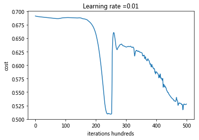

```python
##下面做一个随机梯度和梯度下降的比较
#1.加载数据
train_x,train_y,test_x,test_y = load_data(is_plot=False)
#2.训练
def model(X,y,n_estimator=50000,learning_rate=0.01,is_plot=True):
    grads = {}
    costs = []
    m = X.shape[1]
    layers_dims = [X.shape[0],10,2,1]
    ##1.初始化parameters
    parameters = init(layers_dims)

    for i in range(1,n_estimator+1):
        ##2.向前传播
        a3,cache = forward_propagation(X,parameters)
        ##计算损失函数
        cost = computer_cost(a3,y)
        ##反向传播
        grads = back_grads(X,y,cache)

        ##更新参数
        parameters = update_parameters(parameters,grads,learning_rate)
        ##记录成本
        if i%100 == 0:
            costs.append(cost)
            print_cost=True
            if print_cost:
                print('第'+str(i)+'次迭代，成本值为：'+str(cost))
     ##绘制成本曲线
    if is_plot:
        plt.plot(costs)
        plt.ylabel('cost')
        plt.xlabel('iterations hundreds')
        plt.title('Learning rate ='+str(learning_rate))
        plt.show()
model(train_x,train_y)
```

1.mini-batch梯度下降法1.1.把训练集打乱

```python
import math
def random_mini_batches(X,y,mini_batch_size,seed=0):
    np.random.seed(seed)
    m = X.shape[1]
    mini_batches = []

    #1.打乱顺序
    permutation = list(np.random.permutation(m)) #返回一个长度为m的随机数组
    shuffled_X = X[:,permutation]
    shuffled_y = y[:,permutation].reshape((1,m))

    #2.分割
    num_complete_minibatches = math.floor(m/mini_batch_size)
    for k in range(0,num_complete_minibatches):
        mini_batch_X = shuffled_X[:,k*mini_batch_size:(k+1)*mini_batch_size]
        mini_batch_y = shuffled_y[:,k*mini_batch_size:(k+1)*mini_batch_size]
        mini_batch = (mini_batch_X,mini_batch_y)
        mini_batches.append(mini_batch)

    if m%mini_batch_size != 0 :
        mini_batch_X = shuffled_X[:,mini_batch_size*num_complete_minibatches:]
        mini_batch_y = shuffled_y[:,mini_batch_size*num_complete_minibatches:]
        mini_batch = (mini_batch_X,mini_batch_y)
        mini_batches.append(mini_batch)

    return mini_batches
```

2.初始化速度变量说明：由于小批量的梯度下降只是在局部的参数更新，相对于梯度下降而言，其参数更新会存在震荡现象，但最终会走向收敛，使用动量的目的就是为了减少这种震荡的幅度。 动量考虑了过去的梯度以更加平滑的方式进行参数的更新（指数加权平均值）

```python
def initialize_velocity(parameters):
    L = len(parameters)//2
    v = {}
    for i in range(L):
        v['dW'+str(i+1)] = np.zeros_like(parameters['W'+str(i+1)])
        v['db'+str(i+1)] = np.zeros_like(parameters['b'+str(i+1)])
    return v
```

3.momentum算法

```python
def update_parameters_with_momentun(parameters,grads,v,beta,learning_rate):
    L = len(parameters)//2
    for i in range(L):
        #momentun
        v['dW'+str(i+1)] = beta*v['dW'+str(i+1)]+(1-beta)*grads['dW'+str(i+1)]
        v['db'+str(i+1)] = beta*v['db'+str(i+1)]+(1-beta)*grads['db'+str(i+1)]

        #update
        parameters['W'+str(i+1)] = parameters['W'+str(i+1)]-learning_rate*v['dW'+str(i+1)]
        parameters['b'+str(i+1)] = parameters['b'+str(i+1)]-learning_rate*v['db'+str(i+1)]

    return parameters,v
```

```python
#测试momentun算法
import testCase
parameters,grads,v = testCase.update_parameters_with_momentum_test_case()
update_parameters_with_momentun(parameters,grads,v,beta=0.9,learning_rate=0.01)
print(parameters)
```

```
{'W1': array([[ 1.62544598, -0.61290114, -0.52907334],
       [-1.07347112,  0.86450677, -2.30085497]]), 'b1': array([[ 1.74493465],
       [-0.76027113]]), 'W2': array([[ 0.31930698, -0.24990073,  1.4627996 ],
       [-2.05974396, -0.32173003, -0.38320915],
       [ 1.13444069, -1.0998786 , -0.1713109 ]]), 'b2': array([[-0.87809283],
       [ 0.04055394],
       [ 0.58207317]])}
```

说明：当beta等于0时，那么momentun算法就退化到标准的梯度下降算法； 当beta越来越大是，每一次进行参数更新时，dw这一项就更加依赖于上一次的dw，相应的本轮的dw考虑的就较小一些，那么绘制出来的曲线就更加平滑一些。 当beta等于1时，也就是本轮的dw完全依赖于上一轮的dw，和本轮的dw没有关系Adam算法说明：Adam算法是momentun算法和RMSProp算法的结合。 过程： 1.计算上一轮的指数加权平均数，并将其存储为变量v和v_ 2.计算上一轮的平方的指数加权平均数，并将其存储为变量s和s_ 3.根据1，2更新参数

```python
def initialize_Adam(parameters):
    L = len(parameters)//2 ##get layyer_size

    v = {}  ##momentun
    s = {}  ##RMSProp
    for i in range(L):
        v['dW'+str(i+1)] = np.zeros_like(parameters['W'+str(i+1)])
        v['db'+str(i+1)] = np.zeros_like(parameters['b'+str(i+1)])

        s['dW'+str(i+1)] = np.zeros_like(parameters['W'+str(i+1)])
        s['db'+str(i+1)] = np.zeros_like(parameters['b'+str(i+1)])

    return (v,s)
```

```python
def update_parameters_with_Adam(parameters,v,s,grads,t,beta1=0.9,beta2=0.999,epsion=1e-8,learning_rate=0.01):
    L = len(parameters)//2  ##get layer_size
    v_corrected = {}
    s_corrected = {}
    for i in range(L):
        v['dW'+str(i+1)] = beta1*v['dW'+str(i+1)]+(1-beta1)*grads['dW'+str(i+1)]
        v['db'+str(i+1)] = beta1*v['db'+str(i+1)]+(1-beta1)*grads['db'+str(i+1)]
        ##偏差
        v_corrected['dW'+str(i+1)] = v['dW'+str(i+1)]/(1-np.power(beta1,t))
        v_corrected['db'+str(i+1)] = v['db'+str(i+1)]/(1-np.power(beta1,t))

        s['dW'+str(i+1)] = beta2*s['dW'+str(i+1)]+(1-beta2)*np.square(grads['dW'+str(i+1)])
        s['db'+str(i+1)] = beta2*s['db'+str(i+1)]+(1-beta2)*np.square(grads['db'+str(i+1)])
        ##偏差
        s_corrected['dW'+str(i+1)] = s['dW'+str(i+1)]/(1-np.power(beta2,t))
        s_corrected['db'+str(i+1)] = s['db'+str(i+1)]/(1-np.power(beta2,t))
        ##更新参数
        parameters['W'+str(i+1)] = parameters['W'+str(i+1)]-learning_rate*(v_corrected['dW'+str(i+1)]/np.sqrt(s_corrected['dW'+str(i+1)]+epsion))
        parameters['b'+str(i+1)] = parameters['b'+str(i+1)]-learning_rate*(v_corrected['db'+str(i+1)]/np.sqrt(s_corrected['db'+str(i+1)]+epsion))
    return (parameters,v,s)
```

```python
#测试Adam算法
parameters,grads,v,s = testCase.update_parameters_with_adam_test_case()
update_parameters_with_Adam(parameters,v,s,grads,t=2)
```

```
({'W1': array([[ 1.63178673, -0.61919778, -0.53561312],
         [-1.08040999,  0.85796626, -2.29409733]]),
  'W2': array([[ 0.32648046, -0.25681174,  1.46954931],
         [-2.05269934, -0.31497584, -0.37661299],
         [ 1.14121081, -1.09245036, -0.16498684]]),
  'b1': array([[ 1.75225313],
         [-0.75376553]]),
  'b2': array([[-0.88529978],
         [ 0.03477238],
         [ 0.57537385]])},
 {'dW1': array([[-0.11006192,  0.11447237,  0.09015907],
         [ 0.05024943,  0.09008559, -0.06837279]]),
  'dW2': array([[-0.02678881,  0.05303555, -0.06916608],
         [-0.03967535, -0.06871727, -0.08452056],
         [-0.06712461, -0.00126646, -0.11173103]]),
  'db1': array([[-0.01228902],
         [-0.09357694]]),
  'db2': array([[0.02344157],
         [0.16598022],
         [0.07420442]])},
 {'dW1': array([[0.00121136, 0.00131039, 0.00081287],
         [0.0002525 , 0.00081154, 0.00046748]]),
  'dW2': array([[7.17640232e-05, 2.81276921e-04, 4.78394595e-04],
         [1.57413361e-04, 4.72206320e-04, 7.14372576e-04],
         [4.50571368e-04, 1.60392066e-07, 1.24838242e-03]]),
  'db1': array([[1.51020075e-05],
         [8.75664434e-04]]),
  'db2': array([[5.49507194e-05],
         [2.75494327e-03],
         [5.50629536e-04]])})
```

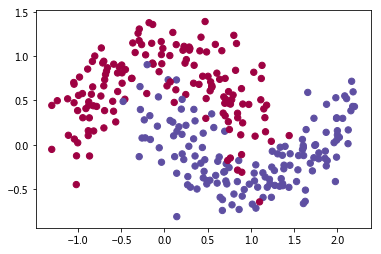

```python
##记载数据集
import opt_utils
train_x,train_y = opt_utils.load_dataset(is_plot=True)
```

```python
##定义模型
def model(X,y,layer_dim,optimizer,learning_rate=0.0007,
         mini_batch_size=64,beta=0.9,beta1=0.9,beta2=0.999,
         epsilon=1e-8,num_epochs=10000,print_cost=True,is_plot=True):
    L = len(layer_dim)
    costs = []
    t = 0
    seed=2018
    parameters = opt_utils.initialize_parameters(layer_dim)

    if optimizer == 'gd':
        pass
    elif optimizer == 'momentun':
        v = initialize_velocity(parameters)
    elif optimizer=='adam':
        v,s = initialize_Adam(parameters)
    else:
        print('optimizer参数错误，程序退出')
        exit(1)
    for i in range(num_epochs):
        seed = seed+1
        mini_batches = random_mini_batches(X,y,mini_batch_size,seed)
        for mini_batch in mini_batches:
            (minibatch_x,minibatch_y) = mini_batch
            ##向前传播
            a3,cache = opt_utils.forward_propagation(minibatch_x,parameters)

            ##计算损失
            cost = opt_utils.compute_cost(a3,minibatch_y)

            ##反向传播
            grads = opt_utils.backward_propagation(minibatch_x,minibatch_y,cache)

            #更新参数
            if optimizer == 'gd':
                parameters = update_parameters_with_gd(parameters,grads,learning_rate)
            elif optimizer == 'momentun':
                parameters,v = update_parameters_with_momentun(parameters,grads,v,beta,learning_rate)
            elif optimizer == 'adam':
                t = t+1
                parameters,v,s = update_parameters_with_Adam(parameters,v,s,grads,t,beta1,beta2,epsilon,learning_rate)
        if i %100 == 0:
            costs.append(cost)
            if print_cost and i%100 ==0:
                print('第'+str(i)+'次遍历整个数据集，当前误差为'+str(cost))
    if is_plot:
        plt.plot(costs)
        plt.ylabel('cost')
        plt.xlabel('epochs (per 100)')
        plt.title("Learning rate = " + str(learning_rate))
        plt.show()

    return parameters
```

```
第0次遍历整个数据集，当前误差为0.6979367070481332
第100次遍历整个数据集，当前误差为0.6809759955331824
第200次遍历整个数据集，当前误差为0.731055575107093
第300次遍历整个数据集，当前误差为0.7103415647122406
第400次遍历整个数据集，当前误差为0.6772992161760627
第500次遍历整个数据集，当前误差为0.6844396195339256
第600次遍历整个数据集，当前误差为0.6602386609165817
第700次遍历整个数据集，当前误差为0.6764748709456312
第800次遍历整个数据集，当前误差为0.6410276656627514
第900次遍历整个数据集，当前误差为0.6989259546328973
第1000次遍历整个数据集，当前误差为0.651242519389141
第1100次遍历整个数据集，当前误差为0.6600099232227392
第1200次遍历整个数据集，当前误差为0.6567801030132561
第1300次遍历整个数据集，当前误差为0.680098476758943
第1400次遍历整个数据集，当前误差为0.6242324023123429
第1500次遍历整个数据集，当前误差为0.6552614577146645
第1600次遍历整个数据集，当前误差为0.6435808367363424
第1700次遍历整个数据集，当前误差为0.6142131021954633
第1800次遍历整个数据集，当前误差为0.6364641753896898
第1900次遍历整个数据集，当前误差为0.6263171968417102
第2000次遍历整个数据集，当前误差为0.6371993457654749
第2100次遍历整个数据集，当前误差为0.6341959292353341
第2200次遍历整个数据集，当前误差为0.5599504207959115
第2300次遍历整个数据集，当前误差为0.6515044591159685
第2400次遍历整个数据集，当前误差为0.6134303993773662
第2500次遍历整个数据集，当前误差为0.6521542074436186
第2600次遍历整个数据集，当前误差为0.6141287071761763
第2700次遍历整个数据集，当前误差为0.5860274380510454
第2800次遍历整个数据集，当前误差为0.616640964860544
第2900次遍历整个数据集，当前误差为0.634636533428616
第3000次遍历整个数据集，当前误差为0.5939602183194295
第3100次遍历整个数据集，当前误差为0.5919676775289973
第3200次遍历整个数据集，当前误差为0.5833060937939101
第3300次遍历整个数据集，当前误差为0.5504095163721792
第3400次遍历整个数据集，当前误差为0.5778210388216843
第3500次遍历整个数据集，当前误差为0.5133784150057095
第3600次遍历整个数据集，当前误差为0.6072051223602671
第3700次遍历整个数据集，当前误差为0.5853297228640941
第3800次遍历整个数据集，当前误差为0.6335431580315511
第3900次遍历整个数据集，当前误差为0.5265688141107704
```

[output cut: 45 more lines]

```
第8500次遍历整个数据集，当前误差为0.3941631020253526
第8600次遍历整个数据集，当前误差为0.4099629219689211
第8700次遍历整个数据集，当前误差为0.44885285942068365
第8800次遍历整个数据集，当前误差为0.4828241785835415
第8900次遍历整个数据集，当前误差为0.5393265429844395
第9000次遍历整个数据集，当前误差为0.45429827198899647
第9100次遍历整个数据集，当前误差为0.45192252435420827
第9200次遍历整个数据集，当前误差为0.4614183207032564
第9300次遍历整个数据集，当前误差为0.3765038073279234
第9400次遍历整个数据集，当前误差为0.46526366862808066
第9500次遍历整个数据集，当前误差为0.4106524734162745
第9600次遍历整个数据集，当前误差为0.5069794465408151
第9700次遍历整个数据集，当前误差为0.4501222003201734
第9800次遍历整个数据集，当前误差为0.39027711180843294
第9900次遍历整个数据集，当前误差为0.46458059762227866
```

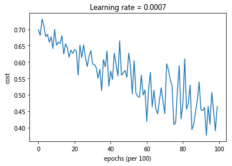

```python
#梯度下降的测试
layer_dims = [train_x.shape[0],5,2,1]
parameters = model(train_x,train_y,layer_dims,optimizer='gd',learning_rate=0.0007,
         mini_batch_size=64,beta=0.9,beta1=0.9,beta2=0.999,
         epsilon=1e-8,num_epochs=10000,print_cost=True,is_plot=True)
```

```python
#绘制分类情况
```

```
Accuracy: 0.7966666666666666
```

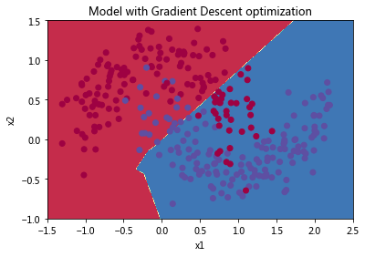

```python
#预测  梯度下降
preditions = opt_utils.predict(train_x,train_y,parameters)

#绘制分类图
plt.title("Model with Gradient Descent optimization")
axes = plt.gca()
axes.set_xlim([-1.5, 2.5])
axes.set_ylim([-1, 1.5])
opt_utils.plot_decision_boundary(lambda x: opt_utils.predict_dec(parameters, x.T), train_x, train_y)
```

```
第0次遍历整个数据集，当前误差为0.6979480773412713
第100次遍历整个数据集，当前误差为0.681048224812188
第200次遍历整个数据集，当前误差为0.7311158135685972
第300次遍历整个数据集，当前误差为0.7104168400169181
第400次遍历整个数据集，当前误差为0.6773443316740922
第500次遍历整个数据集，当前误差为0.6844935980178098
第600次遍历整个数据集，当前误差为0.6603271011703363
第700次遍历整个数据集，当前误差为0.6765474049937853
第800次遍历整个数据集，当前误差为0.6411203734080675
第900次遍历整个数据集，当前误差为0.6989630632867754
第1000次遍历整个数据集，当前误差为0.6513400014923255
第1100次遍历整个数据集，当前误差为0.6600868401510062
第1200次遍历整个数据集，当前误差为0.6568523888043589
第1300次遍历整个数据集，当前误差为0.6801486014415847
第1400次遍历整个数据集，当前误差为0.6243152700418906
第1500次遍历整个数据集，当前误差为0.6553256742720356
第1600次遍历整个数据集，当前误差为0.6436566785533538
第1700次遍历整个数据集，当前误差为0.614312539004033
第1800次遍历整个数据集，当前误差为0.6365590262088568
第1900次遍历整个数据集，当前误差为0.6264190895243054
第2000次遍历整个数据集，当前误差为0.6372755832264742
第2100次遍历整个数据集，当前误差为0.6343073959589898
第2200次遍历整个数据集，当前误差为0.5601169805723901
第2300次遍历整个数据集，当前误差为0.6515810525942729
第2400次遍历整个数据集，当前误差为0.6135221113791121
第2500次遍历整个数据集，当前误差为0.6522886529171832
第2600次遍历整个数据集，当前误差为0.6142253723306859
第2700次遍历整个数据集，当前误差为0.5861330080019395
第2800次遍历整个数据集，当前误差为0.6166836125473062
第2900次遍历整个数据集，当前误差为0.6347285112369894
第3000次遍历整个数据集，当前误差为0.5940475517427826
第3100次遍历整个数据集，当前误差为0.5920468548500388
第3200次遍历整个数据集，当前误差为0.5833929379780181
第3300次遍历整个数据集，当前误差为0.550523824140347
第3400次遍历整个数据集，当前误差为0.5779162784242898
第3500次遍历整个数据集，当前误差为0.5135053851092418
第3600次遍历整个数据集，当前误差为0.6073026216215472
第3700次遍历整个数据集，当前误差为0.5854387510306588
第3800次遍历整个数据集，当前误差为0.6336206602021458
第3900次遍历整个数据集，当前误差为0.5266381306539998
```

[output cut: 45 more lines]

```
第8500次遍历整个数据集，当前误差为0.3943626991395842
第8600次遍历整个数据集，当前误差为0.41013498014678224
第8700次遍历整个数据集，当前误差为0.44913321914611465
第8800次遍历整个数据集，当前误差为0.4828506601110378
第8900次遍历整个数据集，当前误差为0.5394494740602581
第9000次遍历整个数据集，当前误差为0.4544341396027277
第9100次遍历整个数据集，当前误差为0.45198187260531203
第9200次遍历整个数据集，当前误差为0.4614669953275079
第9300次遍历整个数据集，当前误差为0.37670241069134763
第9400次遍历整个数据集，当前误差为0.4655979889735896
第9500次遍历整个数据集，当前误差为0.41097670458187885
第9600次遍历整个数据集，当前误差为0.5068187372311979
第9700次遍历整个数据集，当前误差为0.4501779666795866
第9800次遍历整个数据集，当前误差为0.3908321794492398
第9900次遍历整个数据集，当前误差为0.46457135761736584
```

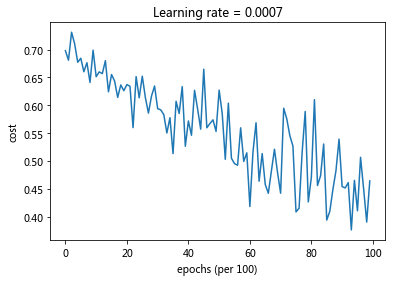

```
Accuracy: 0.7966666666666666
```

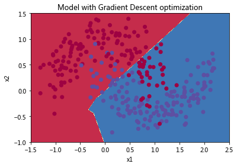

```python
#预测  momentun
#梯度下降的测试
layer_dims = [train_x.shape[0],5,2,1]
parameters = model(train_x,train_y,layer_dims,optimizer='momentun',learning_rate=0.0007,
         mini_batch_size=64,beta=0.9,beta1=0.9,beta2=0.999,
         epsilon=1e-8,num_epochs=10000,print_cost=True,is_plot=True)

preditions = opt_utils.predict(train_x,train_y,parameters)


#绘制分类图
plt.title("Model with Gradient Descent optimization")
axes = plt.gca()
axes.set_xlim([-1.5, 2.5])
axes.set_ylim([-1, 1.5])
opt_utils.plot_decision_boundary(lambda x: opt_utils.predict_dec(parameters, x.T), train_x, train_y)
```

```
第0次遍历整个数据集，当前误差为0.6975358543097153
第100次遍历整个数据集，当前误差为0.5423409124317925
第200次遍历整个数据集，当前误差为0.5192568333437166
第300次遍历整个数据集，当前误差为0.35239462134333793
第400次遍历整个数据集，当前误差为0.37495266807972627
第500次遍历整个数据集，当前误差为0.26835469700146913
第600次遍历整个数据集，当前误差为0.18240444305870263
第700次遍历整个数据集，当前误差为0.16379015380540002
第800次遍历整个数据集，当前误差为0.22096657980919257
第900次遍历整个数据集，当前误差为0.2086919423419447
第1000次遍历整个数据集，当前误差为0.1201778054065741
第1100次遍历整个数据集，当前误差为0.15485176722409474
第1200次遍历整个数据集，当前误差为0.12158207183580468
第1300次遍历整个数据集，当前误差为0.06876758271700577
第1400次遍历整个数据集，当前误差为0.1631987360951211
第1500次遍历整个数据集，当前误差为0.058280009595894744
第1600次遍历整个数据集，当前误差为0.24414881664801308
第1700次遍历整个数据集，当前误差为0.05437492283373666
第1800次遍历整个数据集，当前误差为0.1571609120211534
第1900次遍历整个数据集，当前误差为0.09834950281179632
第2000次遍历整个数据集，当前误差为0.20841482673885584
第2100次遍历整个数据集，当前误差为0.06392464362612421
第2200次遍历整个数据集，当前误差为0.12180956964243224
第2300次遍历整个数据集，当前误差为0.13179201168200755
第2400次遍历整个数据集，当前误差为0.16228618554674895
第2500次遍历整个数据集，当前误差为0.1820893966007879
第2600次遍历整个数据集，当前误差为0.11327323450885313
第2700次遍历整个数据集，当前误差为0.10215951239228373
第2800次遍历整个数据集，当前误差为0.1672414446760915
第2900次遍历整个数据集，当前误差为0.12710002050699865
第3000次遍历整个数据集，当前误差为0.10584754800784571
第3100次遍历整个数据集，当前误差为0.10966979400079663
第3200次遍历整个数据集，当前误差为0.21863656911899373
第3300次遍历整个数据集，当前误差为0.19385064938778626
第3400次遍历整个数据集，当前误差为0.07451103174043595
第3500次遍历整个数据集，当前误差为0.07076080485314407
第3600次遍历整个数据集，当前误差为0.1707123810634702
第3700次遍历整个数据集，当前误差为0.08134588571436531
第3800次遍历整个数据集，当前误差为0.17862405381739574
第3900次遍历整个数据集，当前误差为0.14964237978278194
```

[output cut: 45 more lines]

```
第8500次遍历整个数据集，当前误差为0.1308851461115857
第8600次遍历整个数据集，当前误差为0.15674941111315746
第8700次遍历整个数据集，当前误差为0.05608551659483063
第8800次遍历整个数据集，当前误差为0.14524088482147965
第8900次遍历整个数据集，当前误差为0.08193509694088895
第9000次遍历整个数据集，当前误差为0.13232023424583444
第9100次遍历整个数据集，当前误差为0.1707783766890068
第9200次遍历整个数据集，当前误差为0.16286295501567452
第9300次遍历整个数据集，当前误差为0.0627000455070943
第9400次遍历整个数据集，当前误差为0.03709925472596999
第9500次遍历整个数据集，当前误差为0.06175082368371561
第9600次遍历整个数据集，当前误差为0.15771905489313845
第9700次遍历整个数据集，当前误差为0.11574637367834728
第9800次遍历整个数据集，当前误差为0.0886703168255028
第9900次遍历整个数据集，当前误差为0.22831715085919457
```

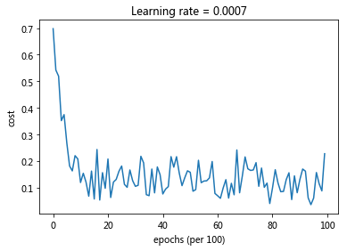

```
Accuracy: 0.94
```

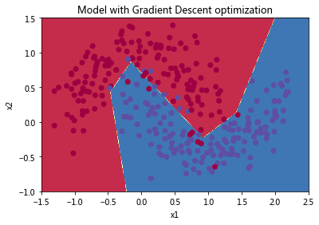

```python
#预测  adam
#梯度下降的测试
layer_dims = [train_x.shape[0],5,2,1]
parameters = model(train_x,train_y,layer_dims,optimizer='adam',learning_rate=0.0007,
         mini_batch_size=64,beta=0.9,beta1=0.9,beta2=0.999,
         epsilon=1e-8,num_epochs=10000,print_cost=True,is_plot=True)

preditions = opt_utils.predict(train_x,train_y,parameters)


#绘制分类图
plt.title("Model with Gradient Descent optimization")
axes = plt.gca()
axes.set_xlim([-1.5, 2.5])
axes.set_ylim([-1, 1.5])
opt_utils.plot_decision_boundary(lambda x: opt_utils.predict_dec(parameters, x.T), train_x, train_y)
```